# Blog de Miguel Angel Huerta

## Basic Inferential Data Analysis

[figure not shown]

# Basic Inferential Data Analysis

## Basic Inferential Data Analysis Instructions

Now in the second portion of the project, we’re going to analyze the ToothGrowth data in the R datasets package.

1. Load the ToothGrowth data and perform some basic exploratory data analyses
2. Provide a basic summary of the data.
3. Use confidence intervals and/or hypothesis tests to compare tooth growth by supp and dose. (Only use the techniques from class, even if there’s other approaches worth considering)
4. State your conclusions and the assumptions needed for your conclusions.

1.- Exploratory Analysis

```r
library(ggplot2)
# Load ToothGrowth data
data("ToothGrowth")
head(ToothGrowth)
```

```
##    len supp dose
## 1  4.2   VC  0.5
## 2 11.5   VC  0.5
## 3  7.3   VC  0.5
## 4  5.8   VC  0.5
## 5  6.4   VC  0.5
## 6 10.0   VC  0.5
```

```r
str(ToothGrowth)
```

```
## 'data.frame':    60 obs. of  3 variables:
##  $ len : num  4.2 11.5 7.3 5.8 6.4 10 11.2 11.2 5.2 7 ...
##  $ supp: Factor w/ 2 levels "OJ","VC": 2 2 2 2 2 2 2 2 2 2 ...
##  $ dose: num  0.5 0.5 0.5 0.5 0.5 0.5 0.5 0.5 0.5 0.5 ...
```

```r
summary(ToothGrowth)
```

```
##       len        supp         dose
##  Min.   : 4.20   OJ:30   Min.   :0.500
##  1st Qu.:13.07   VC:30   1st Qu.:0.500
##  Median :19.25           Median :1.000
##  Mean   :18.81           Mean   :1.167
##  3rd Qu.:25.27           3rd Qu.:2.000
##  Max.   :33.90           Max.   :2.000
```

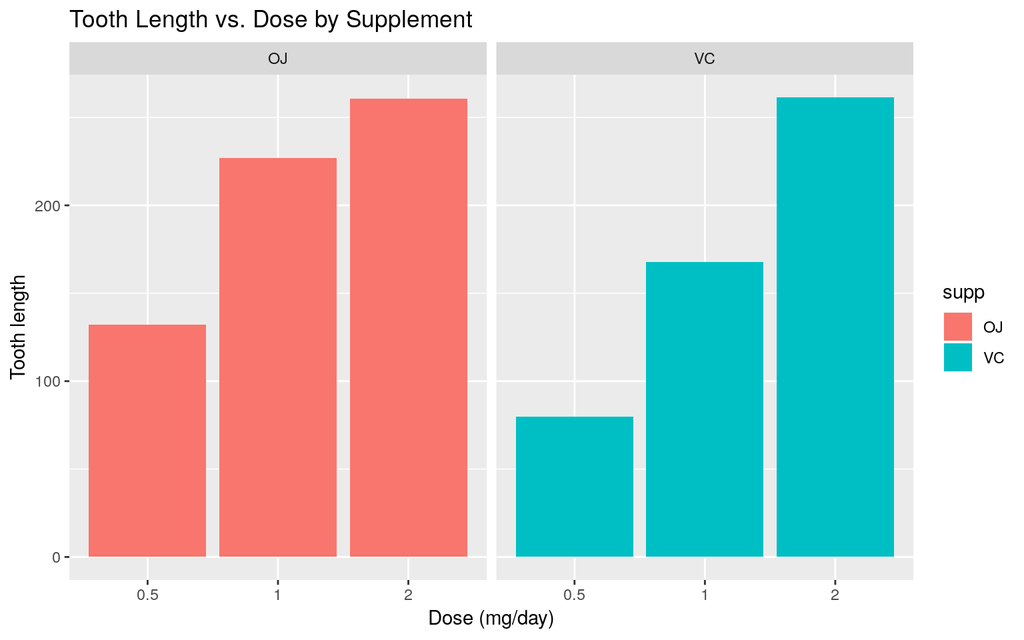

```r
ggplot(ToothGrowth, aes(x=factor(dose), y=len, fill=supp)) +
  geom_bar(stat="identity") +
  facet_grid(. ~ supp) +
  xlab("Dose (mg/day)") +
  ylab("Tooth length") +
  ggtitle("Tooth Length vs. Dose by Supplement")
```

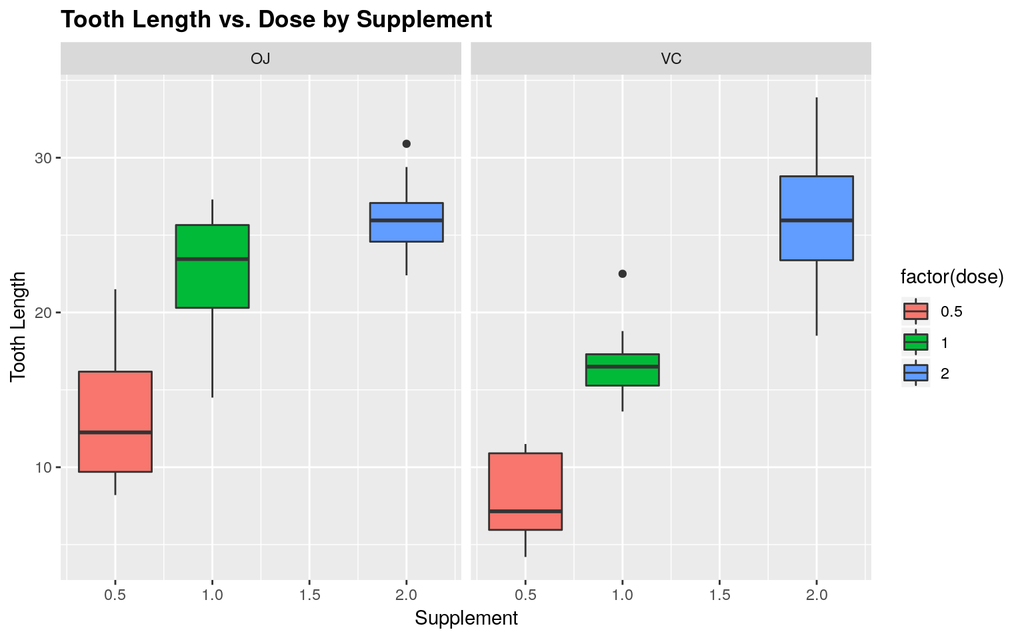

```r
ggplot(aes(x=dose, y=len), data=ToothGrowth) + geom_boxplot(aes(fill=factor(dose)))+ facet_grid(~ supp)+ xlab("Supplement") + ylab("Tooth Length") + ggtitle("Tooth Length vs. Dose by Supplement")+   theme(plot.title = element_text(lineheight=.8, face="bold"))
```

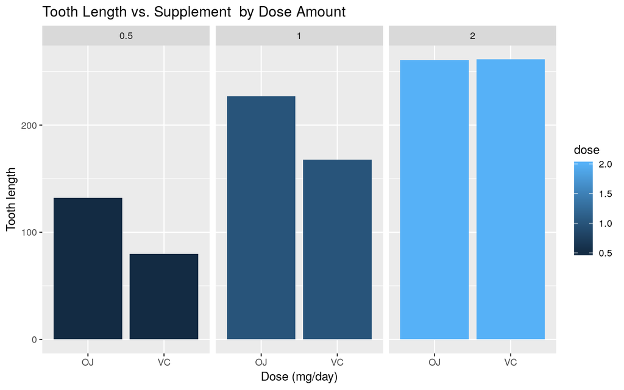

```r
ggplot(ToothGrowth, aes(x=factor(supp), y=len, fill=dose)) +
  geom_bar(stat="identity") +
  facet_grid(. ~ dose) +
  xlab("Dose (mg/day)") +
  ylab("Tooth length") +
  ggtitle("Tooth Length vs. Supplement  by Dose Amount")
```

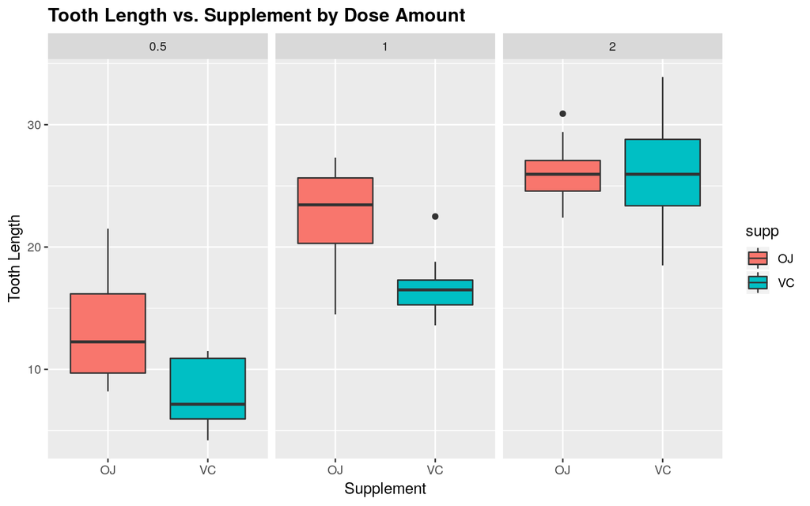

```r
ggplot(aes(x=supp, y=len), data=ToothGrowth) + geom_boxplot(aes(fill=supp))+ facet_grid(~ dose)+ xlab("Supplement") + ylab("Tooth Length") + ggtitle("Tooth Length vs. Supplement by Dose Amount")+   theme(plot.title = element_text(lineheight=.8, face="bold"))
```

2.- Hyphotesis Testing

Use confidence intervals and/or hypothesis tests to compare tooth growth by supp and dose. (Only use the techniques from class, even if there’s other approaches worth considering)

```r
# Supplement
h1 <- t.test(len~supp,data=ToothGrowth)
h1
```

```
##
##  Welch Two Sample t-test
##
## data:  len by supp
## t = 1.9153, df = 55.309, p-value = 0.06063
## alternative hypothesis: true difference in means is not equal to 0
## 95 percent confidence interval:
##  -0.1710156  7.5710156
## sample estimates:
## mean in group OJ mean in group VC
##         20.66333         16.96333
```

```r
# Supplements with Dose amounts 0.5
h2 <- t.test(len ~ supp, data = subset(ToothGrowth, dose == 0.5))
h2
```

```
##
##  Welch Two Sample t-test
##
## data:  len by supp
## t = 3.1697, df = 14.969, p-value = 0.006359
## alternative hypothesis: true difference in means is not equal to 0
## 95 percent confidence interval:
##  1.719057 8.780943
## sample estimates:
## mean in group OJ mean in group VC
##            13.23             7.98
```

```r
# Supplements with Dose amounts 1
h3 <- t.test(len ~ supp, data = subset(ToothGrowth, dose == 1))
h3
```

```
##
##  Welch Two Sample t-test
##
## data:  len by supp
## t = 4.0328, df = 15.358, p-value = 0.001038
## alternative hypothesis: true difference in means is not equal to 0
## 95 percent confidence interval:
##  2.802148 9.057852
## sample estimates:
## mean in group OJ mean in group VC
##            22.70            16.77
```

```r
# Supplements with Dose amounts 2
h4 <- t.test(len ~ supp, data = subset(ToothGrowth, dose == 2))
h4
```

```
##
##  Welch Two Sample t-test
##
## data:  len by supp
## t = -0.046136, df = 14.04, p-value = 0.9639
## alternative hypothesis: true difference in means is not equal to 0
## 95 percent confidence interval:
##  -3.79807  3.63807
## sample estimates:
## mean in group OJ mean in group VC
##            26.06            26.14
```

3.- Conclusions State your conclusions and the assumptions needed for your conclusions.

**Hypothesis1: One supplement delivers more tooth growth than the other**

```r
h1$conf.int
```

```
## [1] -0.1710156  7.5710156
## attr(,"conf.level")
## [1] 0.95
```

```r
paste0("The P value ",h1$p.value,"> 0.05, we cannot reject the null hypothesis since there is no statisical significance. ")
```

```
## [1] "The P value 0.0606345078809341> 0.05, we cannot reject the null hypothesis since there is no statisical significance. "
```

**REJECTED**

**Hypothesis2: One supplement delivers more tooth growth than the other at dose 0.5**

```r
h2$conf.int
```

```
## [1] 1.719057 8.780943
## attr(,"conf.level")
## [1] 0.95
```

```r
h2$p.value
```

```
## [1] 0.006358607
```

```r
paste0("The P value ",h2$p.value,"< 0.05, the difference is statistically significant so we can reject the null hypothesis.The alternative hypothesis that one supplement delivers more tooth growth than the other at  0.5 mg/day  is accepted. ")
```

```
## [1] "The P value 0.0063586067640968< 0.05, the difference is statistically significant so we can reject the null hypothesis.The alternative hypothesis that one supplement delivers more tooth growth than the other at  0.5 mg/day  is accepted. "
```

**ACCEPTED**

**Hypothesis3: One supplement delivers more tooth growth than the other at dose 1**

```r
h3$conf.int
```

```
## [1] 2.802148 9.057852
## attr(,"conf.level")
## [1] 0.95
```

```r
h3$p.value
```

```
## [1] 0.001038376
```

```r
paste0("The P value ",h3$p.value,"< 0.05, the difference is statistically significant so we can reject the null hypothesis.The alternative hypothesis that one supplement delivers more tooth growth than the other at  1 mg/day  is accepted. ")
```

```
## [1] "The P value 0.00103837587229988< 0.05, the difference is statistically significant so we can reject the null hypothesis.The alternative hypothesis that one supplement delivers more tooth growth than the other at  1 mg/day  is accepted. "
```

**ACCEPTED**

**Hypothesis4: One supplement delivers more tooth growth at dose 2**

```r
h4$conf.int
```

```
## [1] -3.79807  3.63807
## attr(,"conf.level")
## [1] 0.95
```

```r
h4$p.value
```

```
## [1] 0.9638516
```

```r
paste0("The P value ",h1$p.value,"> 0.05, we cannot reject the null hypothesis since there is no statisical significance. ")
```

[output not shown]

**REJECTED**

**FINAL CONCLUSION**

We can ensure with less than a %5 of coincidence that at doses of 0.5 mg/day and 1mg/day the tooth length is greater with OJ supplement- than with VC.

Miguel Angel Huerta

12 de marzo de 2018

  [kde.org](https://www.kde.org/)

  [debian](https://www.debian.org/index.es.html)

## Contact

mahdsip@gmail.com